# BIO00058M Dementia Case Study

Examination Number: Y3866839

30/11/2020

## Introduction

Clinical visit data was collected from 150 subjects aged between 60 and 96. Data collected included the subjects age, gender, years of education and socioeconomic status. Each subject underwent MRIs on at least two visits to assess their intracranial volume and whole brain volume. At each visit they were given a score for the Mini-Mental State Examination (MMSE), used in clinical practice to measure cognitive impairment (Arevalo-Rodriguez et al. 2015), and were given a Clinical Dementia Rating.

The Clinical Dementia Rating (CDR) is a global rating device, calculated on the basis of testing six cognitive and behavioural domains. It is based on a five point scale of 0-3; 0 = no dementia, 0.5 = questionable dementia, 1 = mild dementia, 2 = moderate dementia and 3 = severe dementia (Morris 1997).

The analysis performed here combines patient and visit data and tidies the data into a format suitable for analysis. The analysis uses supervised methods of machine learning to predict CDR based on factors associated with increased risk of dementia, such as age (Garre-Olmo 2018), and factors associated with dementia progression, such as intracranial volume (Tate et al. 2011). Two methods of machine learning are used here and are compared.

Analysis was conducted in R (R Core Team 2020) using Rmarkdown (Allaire et al. 2020; Xie, Allaire, and Grolemund 2018; Xie, Dervieux, and Riederer 2020)

## Data Import

Visit data and patient data were stored in separate Excel spreadsheets. The spreadsheets were read into R separately. There are functions that can directly read in and combine two datasets but the datasets in this investigation have different numbers of observations so needed to be read in separately. There were 150 participants in the study (150 observations in patient data) however each patient had multiple visits and MRI scans, so there are 373 observations in the visit data.

```
## tibble [150 x 5] (S3: tbl_df/tbl/data.frame)
##  $ Subject ID: chr [1:150] "OAS2_0001" "OAS2_0002" "OAS2_0004" "OAS2_0005" ...
##  $ Group     : chr [1:150] "Nondemented" "Demented" "Nondemented" "Nondemented" ...
##  $ M_or_F    : chr [1:150] "M" "M" "F" "M" ...
##  $ EDUC      : num [1:150] 14 12 18 12 16 14 12 12 16 12 ...
##  $ SES       : num [1:150] 2 NA 3 4 NA 2 2 3 2 4 ...
```

```
## tibble [373 x 9] (S3: tbl_df/tbl/data.frame)
##  $ Subject ID: chr [1:373] "OAS2_0001" "OAS2_0001" "OAS2_0002" "OAS2_0002" ...
##  $ MRI number: chr [1:373] "MR1" "MR2" "MR1" "MR2" ...
##  $ Visit     : num [1:373] 1 2 1 2 3 1 2 1 2 3 ...
##  $ Age       : num [1:373] 87 88 75 76 80 88 90 80 83 85 ...
##  $ MMSE      : num [1:373] 27 30 23 28 22 28 27 28 29 30 ...
##  $ CDR       : num [1:373] 0 0 0.5 0.5 0.5 0 0 0 0.5 0 ...
##  $ eTIV      : num [1:373] 1987 2004 1678 1738 1698 ...
##  $ nWBV      : num [1:373] 0.696 0.681 0.736 0.713 0.701 0.71 0.718 0.712 0.711 0.705 ...
##  $ ASF       : num [1:373] 0.883 0.876 1.046 1.01 1.034 ...
```

## Data Tidying

The column names in both dataframes are not in a tidy format. Using the `names()` function, the column names can be replaced by tidier names in snake_case.

The visit and patient data were read in as two separate files as they have different amounts of variables. Various ‘join’ functions combine two dataframes (“x” and “y”) via a specified join column, present in both dataframes. In this case the chosen join column was subject_ID. The `inner_join()` function was used here and creates a dataframe which retains all the rows from dataframes x and y, therefore enabling two dataframes with different numbers of rows to be joined. If one dataframe (x) has less rows than the other (y) the rows in x will be duplicated based on the observations in the join column. Here, patient data rows are duplicated for every set of visit data from that patient.

There are a number of NA values within the dataframe, that can be detected using the `is.na()` function. The output of this function is a list of every row and a TRUE/FALSE indicator of NA values. This function has a max print limit, meaning 297 rows are omitted from its output. Hence `any(is.na())` and `which(is.na())` are used. `any(is.na())` provides a simple output of TRUE or FALSE based on whether or not missing values are present. `which(is.na())` determines the positions of the NA values; the output of which can be seen below. There are 21 missing values in the dataframe.

```
##  [1] 1495 1496 1497 1503 1504 1505 1627 1628 1700 1701 1730 1731 1815 1816 1849
## [16] 1850 1851 1852 1853 3342 3343
```

The `str()` function is used to give an overview of the dataframe and shows that a lot of the missing values are in the socioeconomic status column. `na.omit()` is used to remove any rows with missing values. It is important to remove missing values as they would interfere with the Random Forest and Linear Discriminant Analysis. Other functions exist that can predict what the NA values would be and replace them in the dataframe. This is not possible here as socioeconomic status is an independent variable and cannot be predicted from the data provided.

## Linear Discriminant Analysis

Linear Discriminant Analysis (LDA) uses linear combinations of predictors to predict the class of a given observation. The algorithm starts by finding directions that maximise the separation between classes and uses these directions to predict the class of individuals. LDA is performed using the `lda` function from the MASS package (Venables and Ripley 2002). This package is not loaded, as doing so masks the `select` function needed to perform the LDA. Here LDA is performed with testing and training. The dataset is split into train and test datasets, using the `createDataPartition` function from the caret package (Kuhn 2020). The model is built or ‘trained’ on the train dataset, which is 75% of the original. Usually a model is used to determine if specific variables have an effect on a response, and is built on all the data present. However, we cannot be sure that the data we have is generalisable and how well the model would predict responses in a new dataset - this is overfitting. Training the model on 75% of the data, and testing it on the remaining 25% enables us to detect the level of overfitting. If the model performs well on the training set but not on the test set it’s likely the model is overfitting and is therefore not a good model.

Clinical dementia rating can take 4 values - 0, 0.5, 1 and 2 - based on dementia status. In our data there are very few scores of 2. Because the test set is only 25% of the original, it is unlikely to contain any 2s. This means the model cannot predict the scores of the test data as the data and its reference (the predictions of the test data) do not have the same levels. In the CDR scale, 0 = no dementia, 0.5 = questionable dementia, 1 = mild dementia and 2 = moderate dementia. Therefore scores of 1 and 2 can be combined to a score of 1, representing “dementia”. The function `mutate()` is used to create a new column (“CDR_2”), which contains the new CDR scores. `str_replace()` is used to replace matched patterns in a string of characters, so can be used to replace “2” with “1”.

The model is first trained using the `lda()` function. Then the function `predict()` is used to give the CDR scores predicted by the model for each observation in the train set, based on years of education, socioeconomic status, age, MMSE score, intracranial volume, whole brain volume and atlas scaling factor.

The `confusionMatrix` function from the caret package (Kuhn 2020) allows us to see the number of correct predictions of CDR and outputs a measure of accuracy. The model accuracy is 0.7255639 when predicting the CDR of the train data. The P value is less than 0.05, which shows that the model accuracy is significantly better than if it were to just predict the most common class.

```
## Confusion Matrix and Statistics
##
##           Reference
## Prediction   0 0.5   1
##        0   148  46   4
##        0.5   8  26   6
##        1     0   9  19
##
## Overall Statistics
##
##                Accuracy : 0.7256
##                  95% CI : (0.6677, 0.7783)
##     No Information Rate : 0.5865
##     P-Value [Acc > NIR] : 1.658e-06
##
##                   Kappa : 0.4578
##
##  Mcnemar's Test P-Value : 7.206e-07
##
## Statistics by Class:
##
##                      Class: 0 Class: 0.5 Class: 1
## Sensitivity            0.9487    0.32099  0.65517
## Specificity            0.5455    0.92432  0.96203
## Pos Pred Value         0.7475    0.65000  0.67857
## Neg Pred Value         0.8824    0.75664  0.95798
## Prevalence             0.5865    0.30451  0.10902
## Detection Rate         0.5564    0.09774  0.07143
## Detection Prevalence   0.7444    0.15038  0.10526
## Balanced Accuracy      0.7471    0.62266  0.80860
```

```
## Confusion Matrix and Statistics
##
##           Reference
## Prediction  0 0.5  1
##        0   48  17  1
##        0.5  2   8  1
##        1    0   4  7
##
## Overall Statistics
##
##                Accuracy : 0.7159
##                  95% CI : (0.6098, 0.807)
##     No Information Rate : 0.5682
##     P-Value [Acc > NIR] : 0.003075
##
##                   Kappa : 0.4536
##
##  Mcnemar's Test P-Value : 0.002150
##
## Statistics by Class:
##
##                      Class: 0 Class: 0.5 Class: 1
## Sensitivity            0.9600    0.27586  0.77778
## Specificity            0.5263    0.94915  0.94937
## Pos Pred Value         0.7273    0.72727  0.63636
## Neg Pred Value         0.9091    0.72727  0.97403
## Prevalence             0.5682    0.32955  0.10227
## Detection Rate         0.5455    0.09091  0.07955
## Detection Prevalence   0.7500    0.12500  0.12500
## Balanced Accuracy      0.7432    0.61251  0.86357
```

`ggplot()` can be used to plot LD1 vs LD2 in order to visualise how well the different CDRs separate; giving a measure of how well the model is able to predict CDR score. When the model is used to predict the classes on the training dataset, there is a lot of overlap between CDRs. (Figure 1).

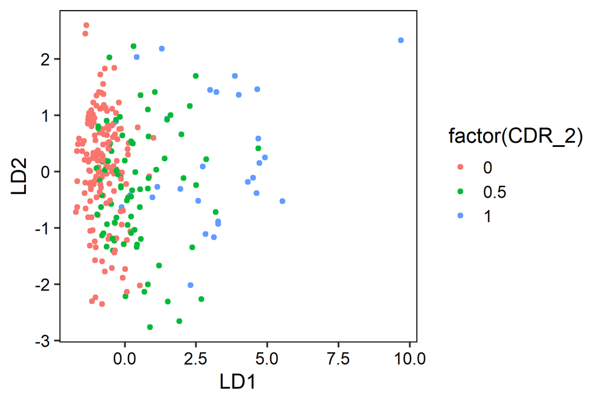

Figure 1: plot of LDA training set

The CDR predictions based on the test dataset separate out somewhat better (Figure 2), but there is still a lot of overlap between 0s and 0.5s. Hence, it is likely that the model would predict scores of 0 and 0.5 incorrectly.

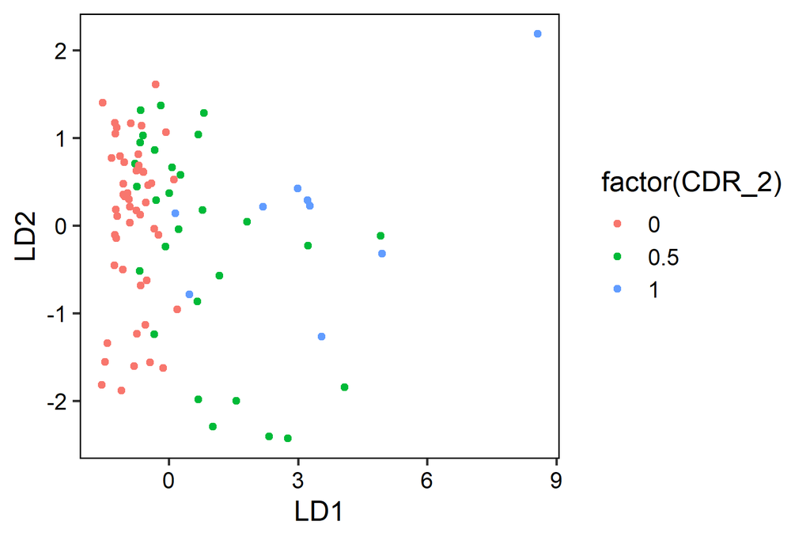

Figure 2: plot of LDA test set

`rbind()` is used to combine the predictions of the train and test datasets so they can be plotted together (Figure 3). Again, there is a large amount of overlap between the scores of 0 and 0.5.

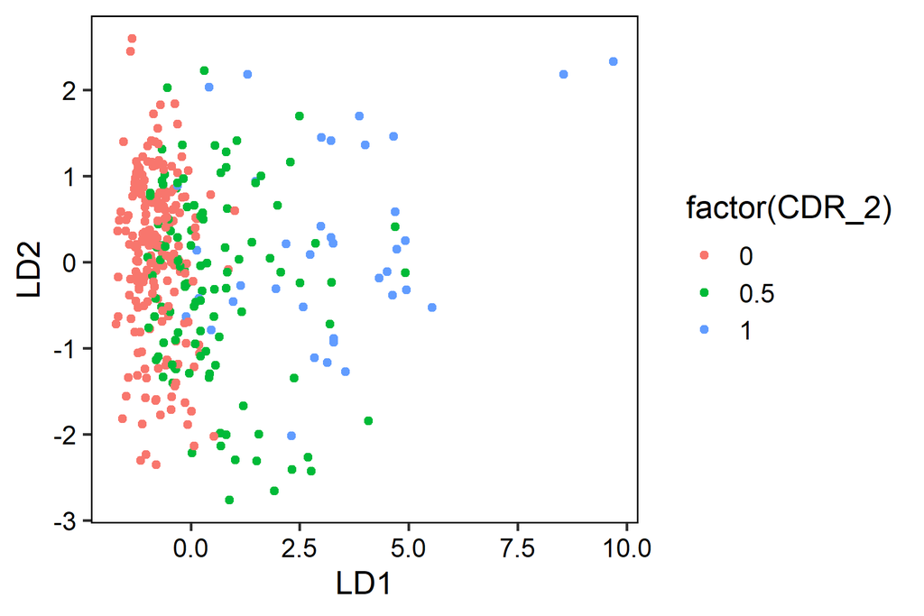

Figure 3: plot of LDA train and test sets

## Random Forest

Random Forest is a machine learning method for classification and regression. It operates by constructing a large number of decision trees from different subsets of a training dataset. The decision trees are then used to output the class that is the mode of the classes output by each of the individual trees. Random forest overcomes the common problem of overfitting which is encountered with Decision Tree methods and is well suited to a smaller sample sizes, like the data in this analysis. Random Forest is peformed using the randomForest package (Liaw and Wiener 2002) however, loading this package using the `library()` function masks the `combine()` function of dplyr (Wickham et al. 2020) and the `margin()` function of ggplot2 (Wickham 2016). It is for this reason double colons are used to access functions from randomForest.

```
##
## Call:
##  randomForest(formula = CDR ~ ., data = dementia_no_na, ntree = 200,      mtry = best_m, importance = TRUE)
##                Type of random forest: classification
##                      Number of trees: 200
## No. of variables tried at each split: 2
##
##         OOB estimate of  error rate: 3.11%
## Confusion matrix:
##       0 0.5  1 2 class.error
## 0   206   0  0 0   0.0000000
## 0.5   0 110  0 0   0.0000000
## 1     0   7 27 1   0.2285714
## 2     0   0  3 0   1.0000000
```

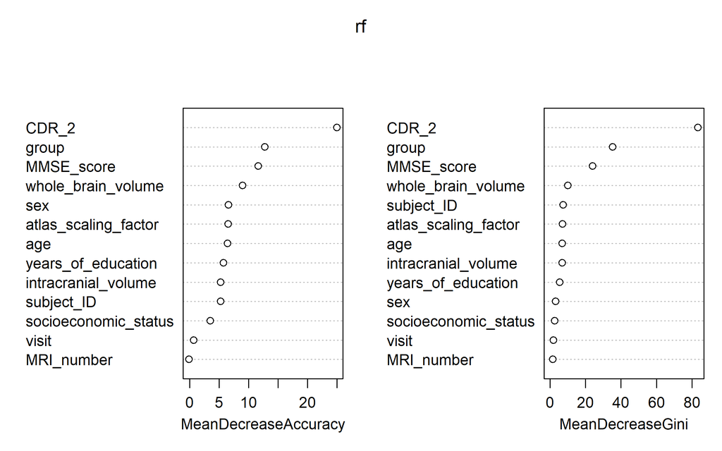

Figure 4: Mean Decrease Accuracy and Mean Decrease Gini

## Conclusion

Both LDA and Random Forest can be used to predict Clinical Dementia Rating. Linear Discriminant Analysis is able to predict CDR with an accuracy of 0.7159091. This is relatively low which could be due to the relatively small size of this dataset; the model is built on just 266 observations and is tested on 88. The Random Forest method is better suited to smaller sample sizes which would explain the low OOB error rate of just 3.11%. Random Forest also shows which variables are the most important in the model. For these reasons, I believe that Random Forest is a better model in predicting Clinical Dementia Rating.

#### **Wordcount**

This document: 1874  
README: 122

**Total: 1996**

## References

Allaire, JJ, Yihui Xie, Jonathan McPherson, Javier Luraschi, Kevin Ushey, Aron Atkins, Hadley Wickham, Joe Cheng, Winston Chang, and Richard Iannone. 2020. *Rmarkdown: Dynamic Documents for R*. https://github.com/rstudio/rmarkdown.

Arevalo-Rodriguez, Ingrid, Nadja Smailagic, Marta Roqué I Figuls, Agustı́n Ciapponi, Erick Sanchez-Perez, Antri Giannakou, Olga L Pedraza, Xavier Bonfill Cosp, and Sarah Cullum. 2015. “Mini-Mental State Examination (MMSE) for the Detection of Alzheimer’s Disease and Other Dementias in People with Mild Cognitive Impairment (MCI).” *Cochrane Database Syst. Rev.*, no. 3 (March): CD010783.

Garre-Olmo, J. 2018. “[Epidemiology of Alzheimer’s Disease and Other Dementias].” *Rev. Neurol.* 66 (11): 377–86.

Kuhn, Max. 2020. *Caret: Classification and Regression Training*. https://CRAN.R-project.org/package=caret.

Liaw, Andy, and Matthew Wiener. 2002. “Classification and Regression by randomForest.” *R News* 2 (3): 18–22. https://CRAN.R-project.org/doc/Rnews/.

Morris, J C. 1997. “Clinical Dementia Rating: A Reliable and Valid Diagnostic and Staging Measure for Dementia of the Alzheimer Type.” *Int. Psychogeriatr.* 9 Suppl 1: 173–6; discussion 177–8.

R Core Team. 2020. *R: A Language and Environment for Statistical Computing*. Vienna, Austria: R Foundation for Statistical Computing. https://www.R-project.org/.

Tate, D F, E S Neeley, M C Norton, J T Tschanz, M J Miller, L Wolfson, C Hulette, et al. 2011. “Intracranial Volume and Dementia: Some Evidence in Support of the Cerebral Reserve Hypothesis.” *Brain Res.* 1385 (April): 151–62.

Venables, W. N., and B. D. Ripley. 2002. *Modern Applied Statistics with S*. Fourth. New York: Springer. http://www.stats.ox.ac.uk/pub/MASS4/.

Wickham, Hadley. 2016. *Ggplot2: Elegant Graphics for Data Analysis*. Springer-Verlag New York. https://ggplot2.tidyverse.org.

Wickham, Hadley, Romain François, Lionel Henry, and Kirill Müller. 2020. *Dplyr: A Grammar of Data Manipulation*. https://CRAN.R-project.org/package=dplyr.

Xie, Yihui, J. J. Allaire, and Garrett Grolemund. 2018. *R Markdown: The Definitive Guide*. Boca Raton, Florida: Chapman; Hall/CRC. https://bookdown.org/yihui/rmarkdown.

Xie, Yihui, Christophe Dervieux, and Emily Riederer. 2020. *R Markdown Cookbook*. Boca Raton, Florida: Chapman; Hall/CRC. https://bookdown.org/yihui/rmarkdown-cookbook.